# Lab 3: Exploring Happiness

Hannah Lo and Yuma Anderson

09/26/2019

## Background

The data we are working with comes from the General Social Survey. It is the result of a yearly opinion survey from the United States. The portion we are working with today is from 1972-2016. The data includes the following:

| Variable | Description |
| --- | --- |
| Happy | Opinion on respondent’s general happiness |
| Year | Year for this respondent |
| Age | Age of respondent |
| Sex | Sex of respondent |
| Marital | Marital Status |
| Degree | Highest achieved degree |
| Finrela | Opinion on respondent’s family income |
| Health | Condition of health |
| Wtssall | Weight Variable for selection bias |
| Partyid | Political party affiliation |
| Polviews | Think of self as liberal or conservative |

These variable description’s can be expounded on further by visiting https://gssdataexplorer.norc.org/.

## Data Cleaning

Before beginning our exploration, cleaning was neccesary. The data included missing values that were all replaced with a unifying ‘NA’.

#### Variable ‘happy’

```r
unique(happy$happy)
```

```
## [1] "NOT TOO HAPPY" "PRETTY HAPPY"  "VERY HAPPY"    NA
```

```r
empty = is.na(happy$happy)
table(empty)
```

```
## empty
## FALSE  TRUE
## 57710  4756
```

#### Variable ‘year’

```r
unique(happy$year)
```

```
##  [1] 1972 1973 1974 1975 1976 1977 1978 1980 1982 1983 1984 1985 1986 1987
## [15] 1988 1989 1990 1991 1993 1994 1996 1998 2000 2002 2004 2006 2008 2010
## [29] 2012 2014 2016
```

```r
empty = is.na(happy$year)
table(empty)
```

```
## empty
## FALSE
## 62466
```

#### Variable ‘age’

```r
unique(happy$age)
```

```
##  [1] "23"          "70"          "48"          "27"          "61"
##  [6] "26"          "28"          "21"          "30"          "56"
## [11] "54"          "49"          "41"          "24"          "62"
## [16] "46"          "57"          "58"          "71"          "53"
## [21] "42"          "20"          "25"          "78"          "35"
## [26] "51"          "76"          "39"          "64"          "50"
## [31] "40"          "43"          "37"          "22"          "31"
## [36] "52"          "47"          "45"          "68"          "63"
## [41] "19"          "55"          "44"          "34"          "36"
## [46] "74"          "69"          "29"          "67"          "75"
## [51] "38"          "73"          "84"          "82"          "72"
## [56] "59"          "33"          "81"          "65"          "32"
## [61] NA            "60"          "80"          "66"          "77"
## [66] "18"          "79"          "83"          "85"          "88"
## [71] "87"          "89 OR OLDER" "86"          "DK"
```

```r
empty = is.na(happy$age)
table(empty)
```

```
## empty
## FALSE  TRUE
## 62246   220
```

```r
nrow(subset(happy,age =='DK'))
```

```
## [1] 1
```

```r
happy$age[happy$age=='DK'] = NA
nrow(subset(happy,age =='DK'))
```

```
## [1] 0
```

#### Variable ‘sex’

```r
unique(happy$sex)
```

```
## [1] "FEMALE" "MALE"
```

#### Variable ‘marital’

```r
unique(happy$marital)
```

```
## [1] "NEVER MARRIED" "MARRIED"       "DIVORCED"      "WIDOWED"
## [5] "SEPARATED"     NA
```

```r
empty = is.na(happy$marital)
table(empty)
```

```
## empty
## FALSE  TRUE
## 62441    25
```

#### Variable ‘degree’

```r
unique(happy$degree)
```

```
## [1] "BACHELOR"       "LT HIGH SCHOOL" "HIGH SCHOOL"    "GRADUATE"
## [5] "JUNIOR COLLEGE" NA               "DK"
```

```r
empty = is.na(happy$degree)
table(empty)
```

```
## empty
## FALSE  TRUE
## 62323   143
```

```r
nrow(subset(happy,degree =='DK'))
```

```
## [1] 30
```

```r
happy$degree[happy$degree=='DK'] = NA
nrow(subset(happy,degree =='DK'))
```

```
## [1] 0
```

#### Variable ‘finrela’

```r
unique(happy$finrela)
```

```
## [1] "AVERAGE"           "ABOVE AVERAGE"     "BELOW AVERAGE"
## [4] "FAR ABOVE AVERAGE" "DK"                "FAR BELOW AVERAGE"
## [7] NA                  "IAP"
```

```r
empty = is.na(happy$finrela)
table(empty)
```

```
## empty
## FALSE  TRUE
## 62316   150
```

```r
table(happy$finrela)
```

```
##
##     ABOVE AVERAGE           AVERAGE     BELOW AVERAGE                DK
##             10691             28307             14029               468
## FAR ABOVE AVERAGE FAR BELOW AVERAGE               IAP
##              1185              3253              4383
```

```r
happy$finrela[(happy$finrela=='IAP'|happy$finrela=='DK')] = NA
table(happy$finrela)
```

```
##
##     ABOVE AVERAGE           AVERAGE     BELOW AVERAGE FAR ABOVE AVERAGE
##             10691             28307             14029              1185
## FAR BELOW AVERAGE
##              3253
```

#### Variable ‘health’

```r
unique(happy$health)
```

```
## [1] "GOOD"      "FAIR"      "EXCELLENT" "POOR"      NA          "DK"
## [7] "IAP"
```

```r
empty = is.na(happy$health)
table(empty)
```

```
## empty
## FALSE  TRUE
## 62376    90
```

```r
table(happy$health)
```

```
##
##        DK EXCELLENT      FAIR      GOOD       IAP      POOR
##        30     13827      8768     20788     16325      2638
```

```r
happy$health[(happy$health=='IAP'|happy$health=='DK')] = NA
table(happy$health)
```

```
##
## EXCELLENT      FAIR      GOOD      POOR
##     13827      8768     20788      2638
```

#### Variable ‘wtssall’

```r
empty = is.na(happy$wtssall)
table(empty)
```

```
## empty
## FALSE
## 62466
```

```r
nrow(subset(happy,(wtssall=='IAP'|wtssall=='DK')))
```

```
## [1] 0
```

#### Variable ‘partyid’

```r
unique(happy$partyid)
```

```
##  [1] "IND,NEAR DEM"       "NOT STR DEMOCRAT"   "INDEPENDENT"
##  [4] "STRONG DEMOCRAT"    "NOT STR REPUBLICAN" "IND,NEAR REP"
##  [7] "STRONG REPUBLICAN"  "OTHER PARTY"        NA
## [10] "DK"
```

```r
empty = is.na(happy$partyid)
table(empty)
```

```
## empty
## FALSE  TRUE
## 62092   374
```

```r
table(happy$partyid)
```

```
##
##                 DK       IND,NEAR DEM       IND,NEAR REP
##                 11               7485               5462
##        INDEPENDENT   NOT STR DEMOCRAT NOT STR REPUBLICAN
##               9474              12942               9661
##        OTHER PARTY    STRONG DEMOCRAT  STRONG REPUBLICAN
##                995               9999               6063
```

```r
happy$partyid[happy$partyid=='DK'] = NA
table(happy$partyid)
```

```
##
##       IND,NEAR DEM       IND,NEAR REP        INDEPENDENT
##               7485               5462               9474
##   NOT STR DEMOCRAT NOT STR REPUBLICAN        OTHER PARTY
##              12942               9661                995
##    STRONG DEMOCRAT  STRONG REPUBLICAN
##               9999               6063
```

#### Variable ‘polviews’

```r
empty = is.na(happy$polviews)
table(empty)
```

```
## empty
## FALSE  TRUE
## 62105   361
```

```r
nrow(subset(happy,(polviews=='IAP'|polviews=='DK')))
```

```
## [1] 9024
```

```r
happy$polviews[(happy$polviews=='IAP'|happy$polviews=='DK')] = NA
nrow(subset(happy,(polviews=='IAP'|polviews=='DK')))
```

```
## [1] 0
```

In total there were 36,391 number of missing values for the following variables: happy, age, marital, degree, finrela, health, partyid, and polviews.

Additionally, variables were cast into correct types for visualization, and the factor variables were put into a reasonable order by the following:

```r
happy$happy = factor(happy$happy)
happy$age[happy$age=='89 OR OLDER'] = '89'
happy$age = as.numeric(happy$age)
happy$sex = factor(happy$sex)
happy$marital = factor(happy$marital, levels = c("NEVER","MARRIED","SEPARATED","DIVORCED","WIDOWED"))
happy$degree = factor(happy$degree, levels = c("LT HIGHSCHOOL","HIGHSCHOOL","JUNIOR COLLEGE","BACHELOR","GRADUATE"))
happy$finrela = factor(happy$finrela,levels = c("FAR BELOW AVERAGE","BELOW AVERAGE","AVERAGE","ABOVE AVERAGE","FAR ABOVE AVERAGE"))
happy$health = factor(happy$health, levels = c("POOR","FAIR","GOOD","EXCELLENT"))
happy$partyid = factor(happy$partyid, levels = c("STRONG DEMOCRAT","NOT STR DEMOCRAT","IND,NEAR DEM","INDEPENDENT","IND,NEAR REP","NOT STR REPUBLICAN","STRONG REPUBLICAN","OTHER PARTY"))
happy$polviews = factor(happy$polviews, levels = c("EXTREMELY LIBERAL","LIBERAL","SLIGHTLY LIBERAL","MODERATE","SLIGHTLY CONSERVATIVE","CONSERVATIVE","EXTREMELY CONSERVATIVE"))
```

### Visualizations

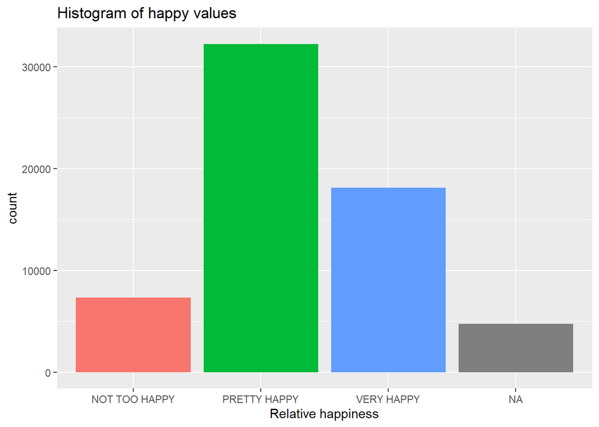

```r
ggplot(happy,aes(happy))+geom_bar(aes(fill = happy))+labs(title="Histogram of happy values", x="Relative happiness","Number of respondents")+theme(legend.position = "none")
```

The variable happy includes 4,756 ‘NA’ values. The value ‘PRETTY HAPPY’ is the most abundant variable.

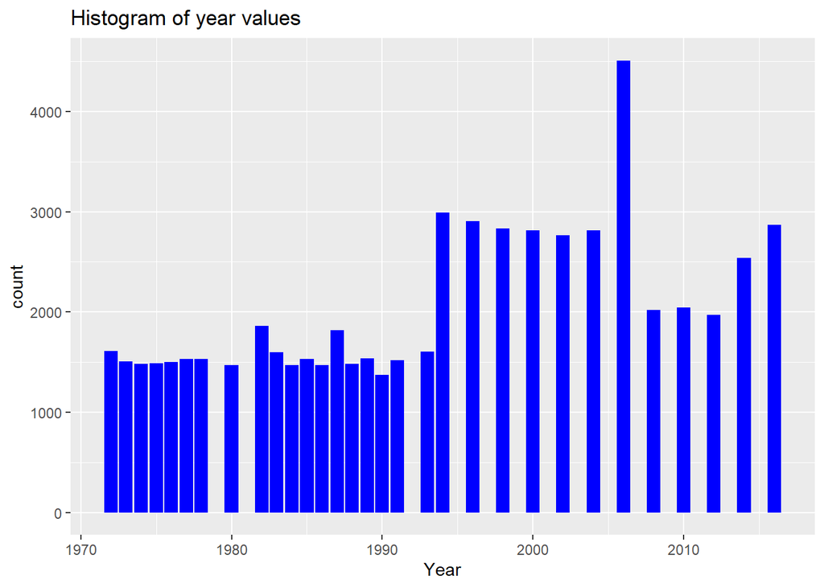

```r
ggplot(happy,aes(year))+geom_bar(fill = 'blue')+labs(title="Histogram of year values", x="Year","Number of respondents")+theme(legend.position = "none")
```

From 1972 to 1995, the survey was completed almost every year. However, it switched to every other year.

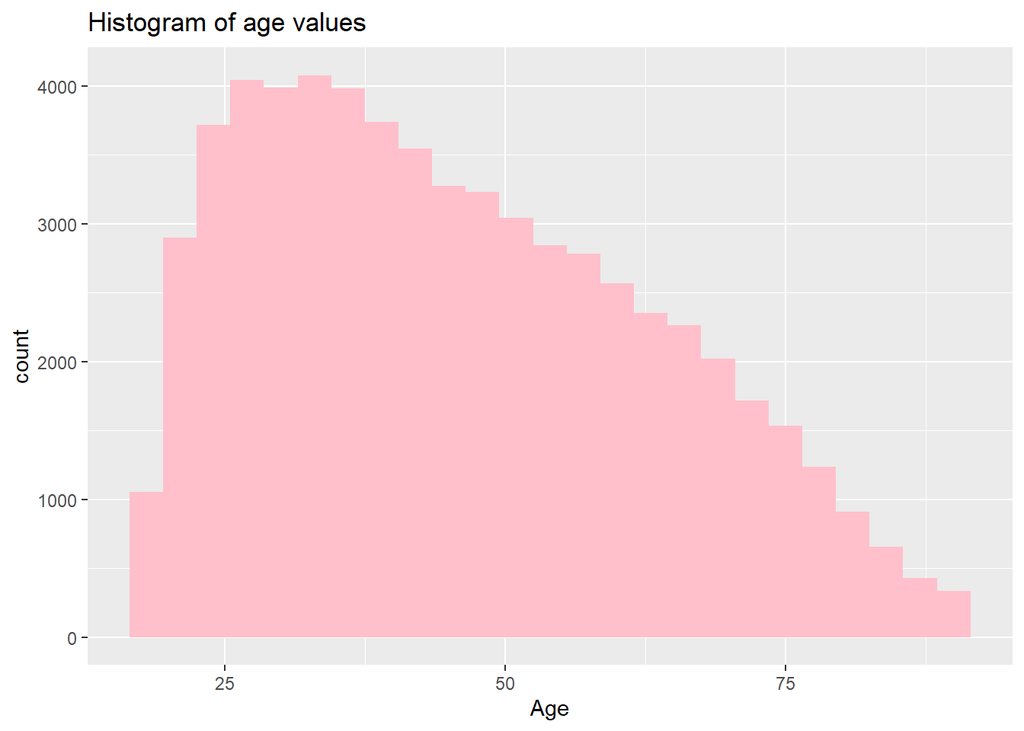

```r
ggplot(happy,aes(age))+geom_histogram(binwidth = 3,fill='pink')+labs(title="Histogram of age values", x="Age","Number of respondents")
```

The distribution of respondent’s age is right-skewed. The mean is greater than the mode.

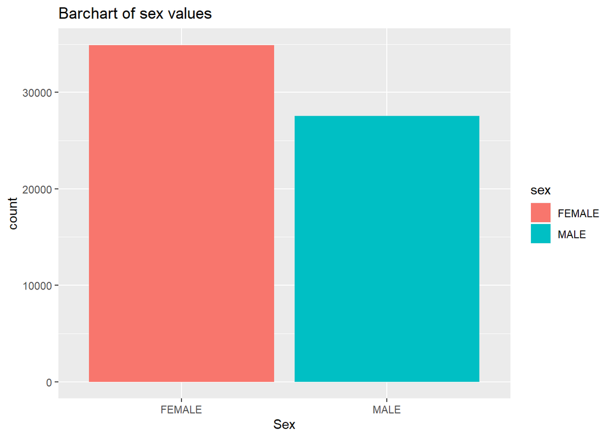

```r
ggplot(happy,aes(sex))+geom_bar(aes(fill = sex))+labs(title="Barchart of sex values", x="Sex","Number of respondents")
```

The data is slightly biased towards the female respondents.

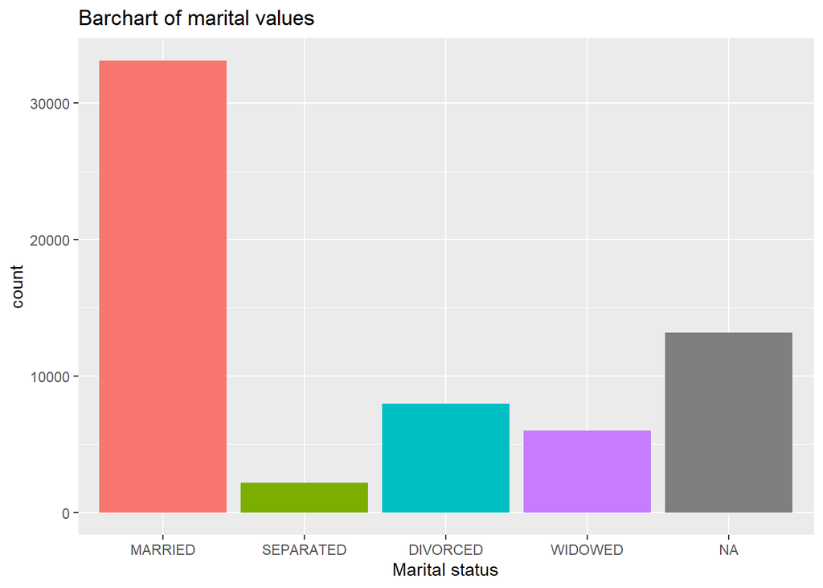

```r
ggplot(happy,aes(marital))+geom_bar(aes(fill = marital))+labs(title="Barchart of marital values", x="Marital status","Number of respondents") + theme(legend.position = 'none')
```

Most respondents are married; however, there is a considerable amount of “NA” values in this variable.

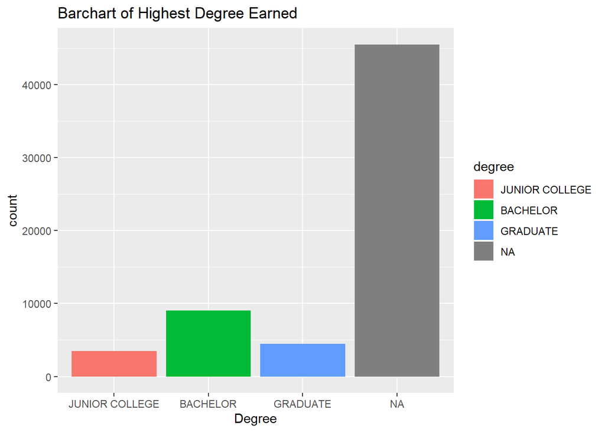

```r
ggplot(happy,aes(degree))+geom_bar(aes(fill = degree))+labs(title="Barchart of Highest Degree Earned", x="Degree","Number of respondents")
```

This variable may not be the most useful in analysis due to the huge amount of ‘NA’ values.

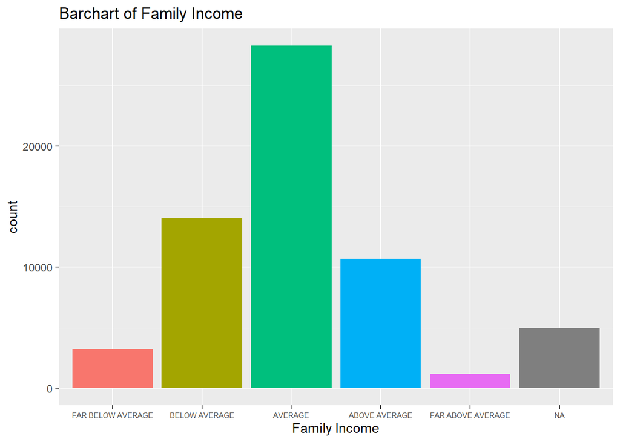

```r
ggplot(happy,aes(finrela))+geom_bar(aes(fill = finrela))+labs(title="Barchart of Family Income", x="Family Income","Number of respondents")+ theme(legend.position='none',axis.text.x=element_text(size=6))
```

The variable ‘finrela’ follows a normal distribution.

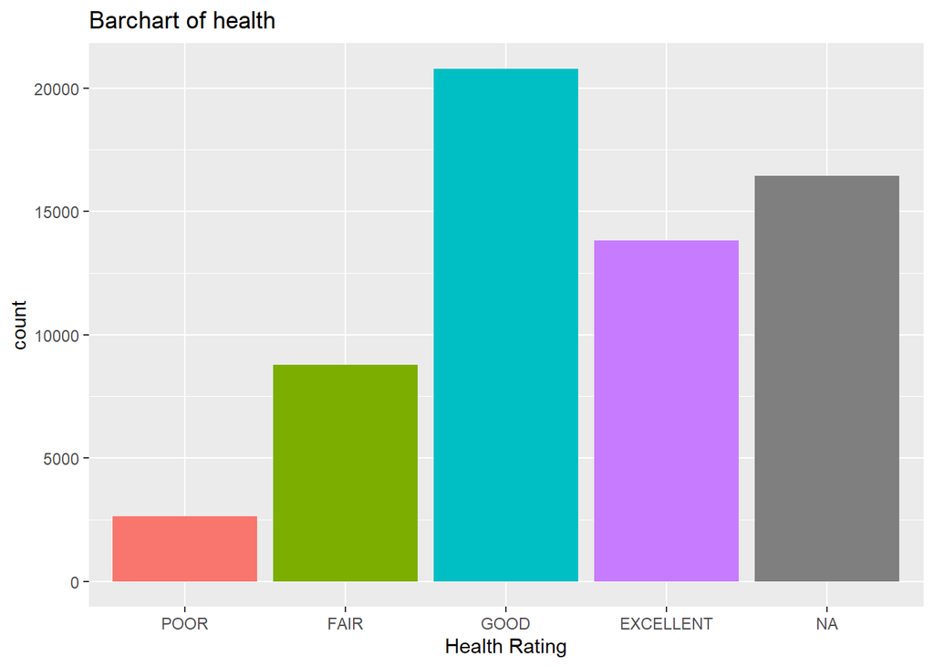

```r
ggplot(happy,aes(health))+geom_bar(aes(fill = health))+labs(title="Barchart of health", x="Health Rating","Number of respondents")+ theme(legend.position='none')
```

Health is another variable that has a considerable amount of ‘NA’ values. This may cause some difficulties in analysis.

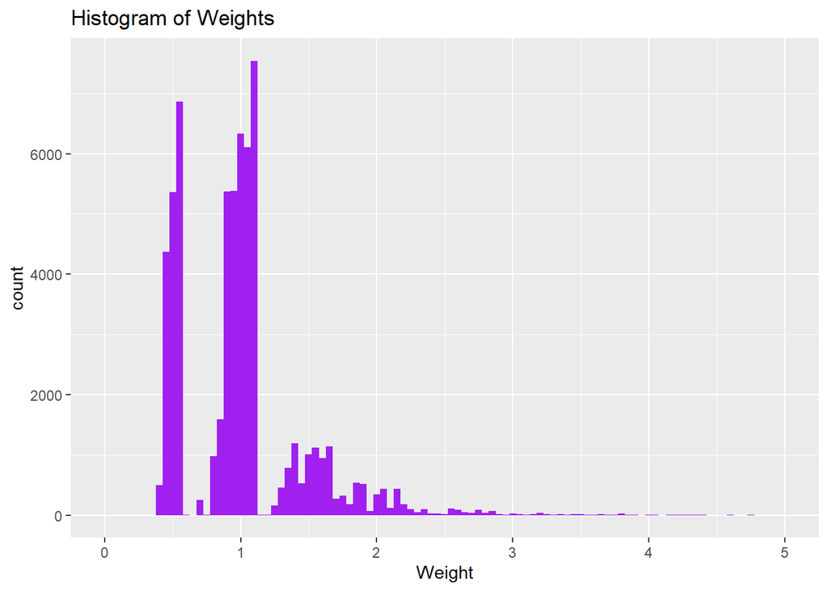

```r
ggplot(happy,aes(wtssall))+geom_histogram(binwidth = .05, fill = 'purple')+labs(title="Histogram of Weights", x="Weight","Number of respondents")+xlim(0,5)
```

The weight variable is in three clusters. The first two clusters are much larger than the third.

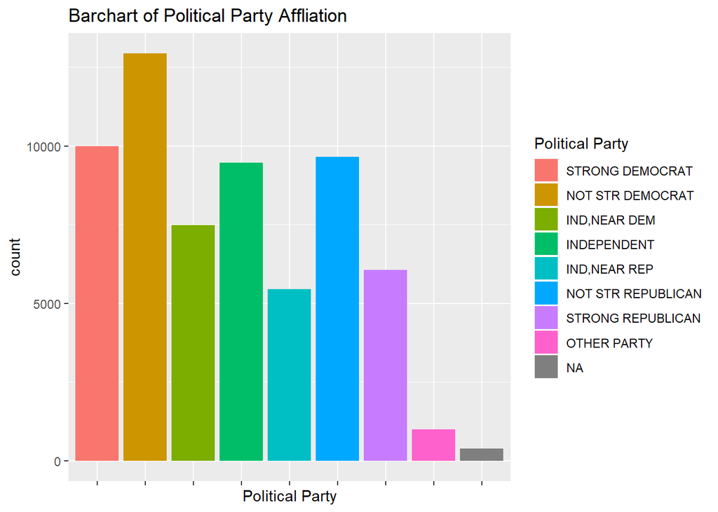

```r
ggplot(happy,aes(partyid))+geom_bar(aes(fill = partyid))+labs(title="Barchart of Political Party Affliation", x="Political Party","Number of respondents")+ theme(axis.text.x=element_blank())+scale_fill_discrete(name = "Political Party")
```

The political party of the respondents are slightly focused towards the Democrat side.

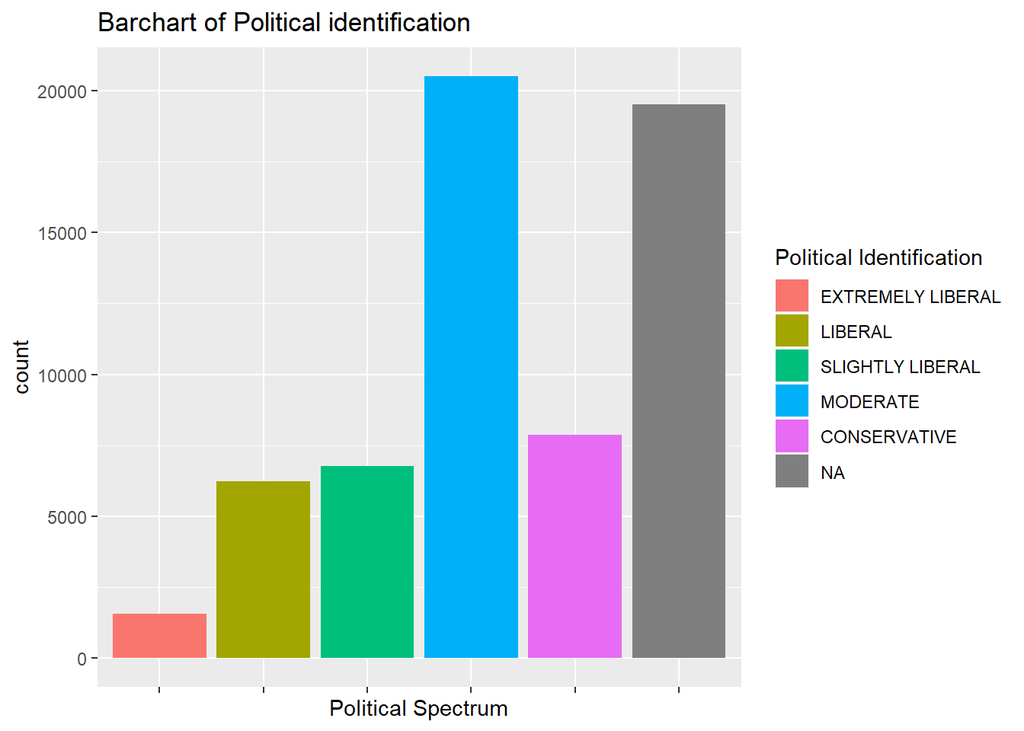

```r
ggplot(happy,aes(polviews))+geom_bar(aes(fill = polviews))+labs(title="Barchart of Political identification", x="Political Spectrum","Number of respondents")+ theme(axis.text.x=element_blank())+scale_fill_discrete(name = "Political Identification")
```

The ‘polviews’ variable has many ‘NA’ values also. Most people identify as moderate which could contrast with the ‘polyid’ variable.

## Data Exploration

Two variables of interest are `HAPPY` and `YEAR`. Their distributions are as follow:

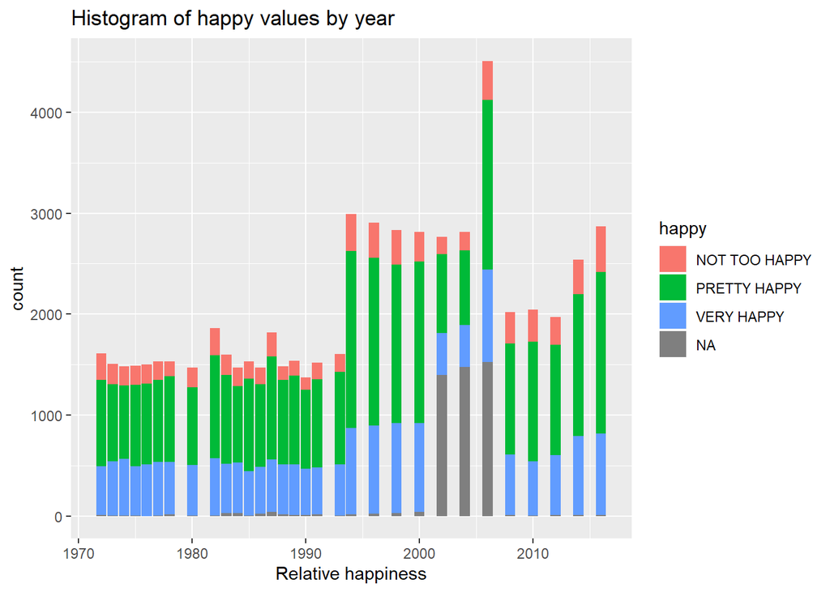

```r
ggplot(happy,aes(year))+geom_bar(aes(fill = happy))+labs(title="Histogram of happy values by year", x="Relative happiness","Number of respondents")+theme()
```

The happiness ratings for every year appear to be evenly distributed every year except the 2002-2006 values, which have high NA values and drastic changes in respondents.

The distribution for `Happy by year` is relatively normal, suggesting that the the average amount of happiness is not dependent on the year variable alone.

Two variables of interest are `HAPPY` and `AGE`. Their distributions are as follow:

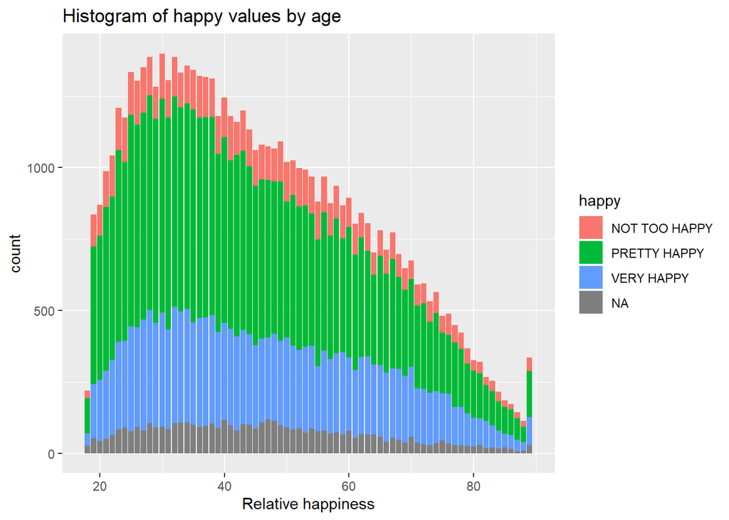

```r
ggplot(happy,aes(age))+geom_bar(aes(fill = happy))+labs(title="Histogram of happy values by age", x="Relative happiness","Number of respondents")+theme()
```

The distribution for `happy by age` is `right-skewed`, suggesting that `people who are younger are happier.` This could be due to the fact that there are more younger respondents in the data. There is also a larger number of people aged 20-40 who respond `not too happy` than people aged 80+.

Two variables of interest are `HAPPY` and `SEX`. Their distributions are as follow:

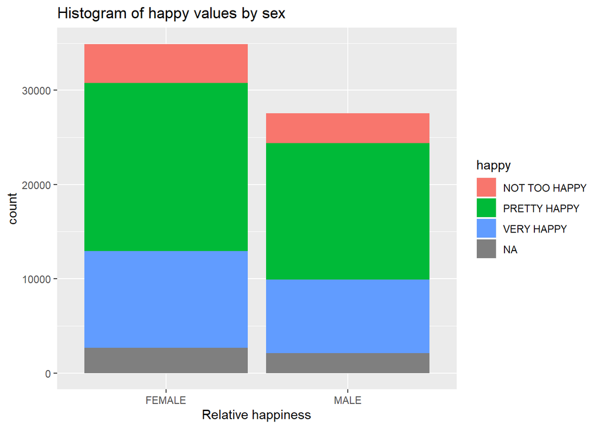

```r
ggplot(happy,aes(sex))+geom_bar(aes(fill = happy))+labs(title="Histogram of happy values by sex", x="Relative happiness","Number of respondents")+theme()
```

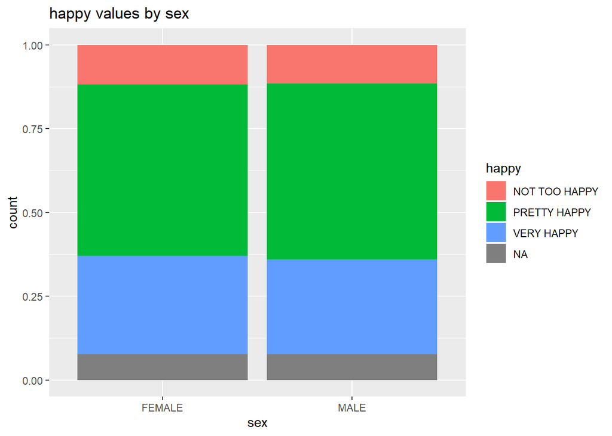

```r
ggplot(happy,aes(x =sex,fill=happy))+geom_bar(position="fill")+labs(title="happy values by sex", x="sex")
```

The distribution for `happy by sex` is `normal`, suggesting that happiness is evenly distributed among the sexes, even though there are a larger number of female respondents.

Two variables of interest are `HAPPY` and `FINRELA`. Their distributions are as follow:

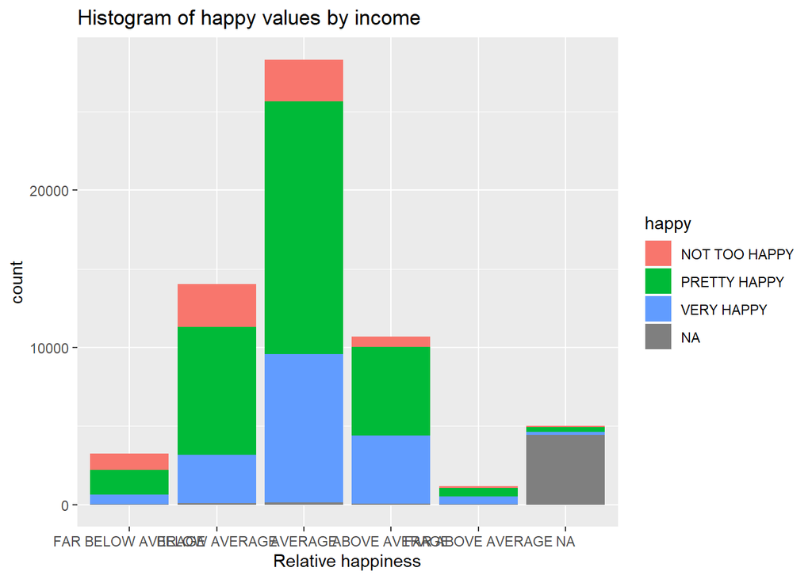

```r
ggplot(happy,aes(finrela))+geom_bar(aes(fill = happy))+labs(title="Histogram of happy values by income", x="Relative happiness","Number of respondents")+theme()
```

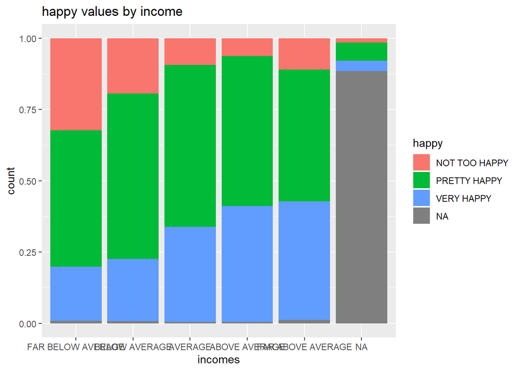

```r
ggplot(happy,aes(x =finrela,fill=happy))+geom_bar(position="fill")+labs(title="happy values by income", x="incomes")
```

The distribution for `happy by income` is `normal`, and shows that there is correlation between income and happiness. Higher incomes have higher numbers of ‘very happy’ and ‘pretty happy’ ratings, while the ‘far below average’ income has the higest ‘not too happy’ rating.

Two variables of interest are `HAPPY` and `WTSSALL`. Their distributions are as follow:

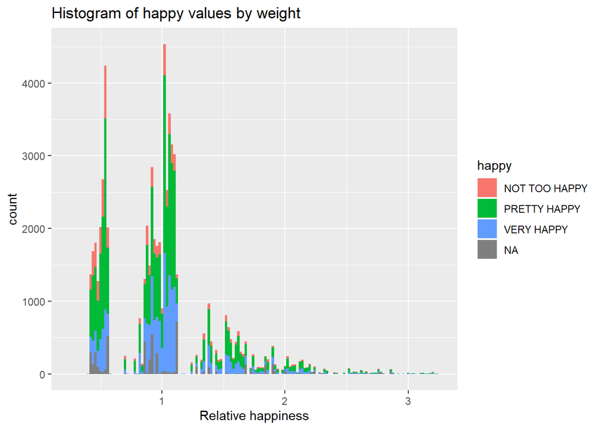

```r
ggplot(happy,aes(wtssall))+geom_histogram(binwidth = .02, aes(fill = happy))+ xlim(0.25, 3.25)+labs(title="Histogram of happy values by weight", x="Relative happiness","Number of respondents")+theme()
```

The distribution for `happy by weight` is `right skewed` with 2 large clusters. There are higher numbers of respondents with ‘not too happy’ in the largest lower weight clusters, but that is most likely due to the higher number of respondents and not the actual relative happiness based on weight.

Two variables of interest are `HAPPY` and `PARTYID`. Their distributions are as follow:

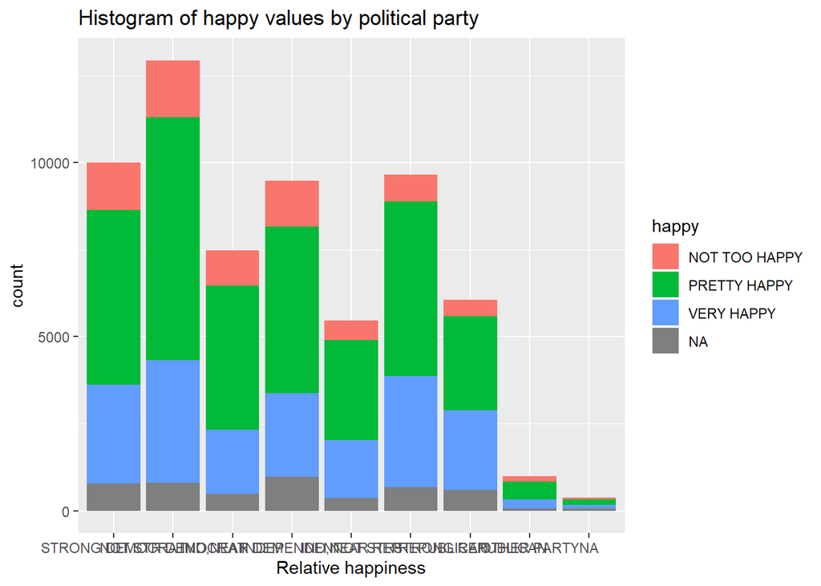

```r
ggplot(happy,aes(partyid))+geom_bar(aes(fill = happy))+labs(title="Histogram of happy values by political party", x="Relative happiness","Number of respondents")+theme()
```

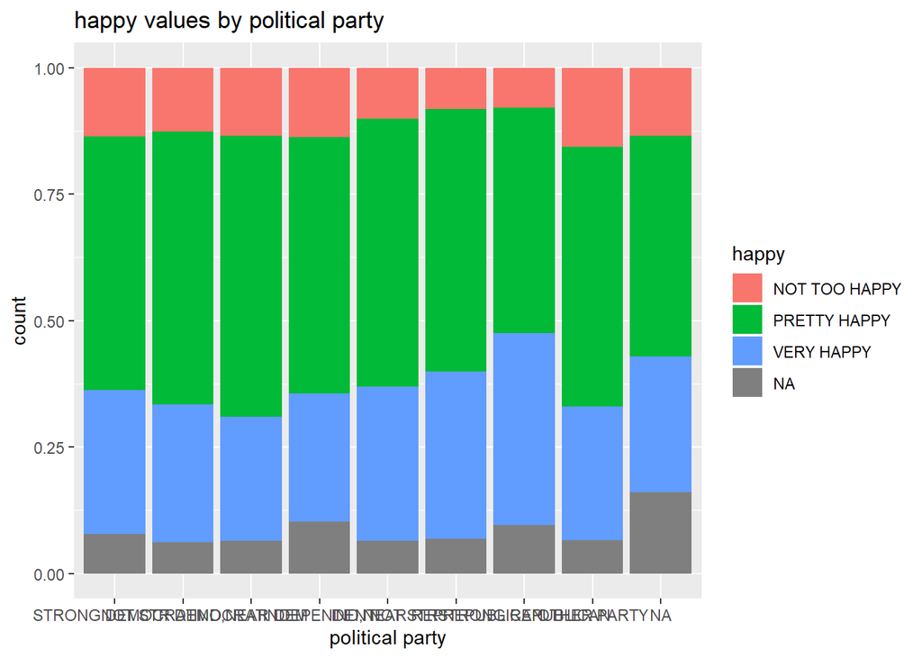

```r
ggplot(happy,aes(x =partyid,fill=happy))+geom_bar(position="fill")+labs(title="happy values by political party", x="political party")
```

The distribution for `happy by political party` is `right skewed`, with a larger number of Democrat and moderate respondents. There are a larger number of respondents that are ‘very happy’ and ‘strong republicans’.

Two variables of interest are `HAPPY` and `POLVIEWS`. Their distributions are as follow:

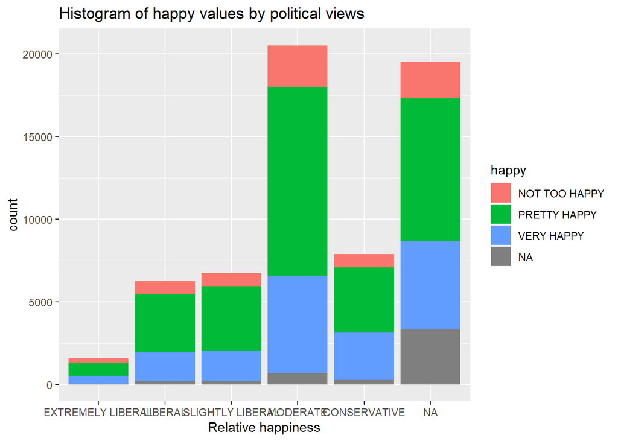

```r
ggplot(happy,aes(polviews))+geom_bar(aes(fill = happy))+labs(title="Histogram of happy values by political views", x="Relative happiness","Number of respondents")+theme()
```

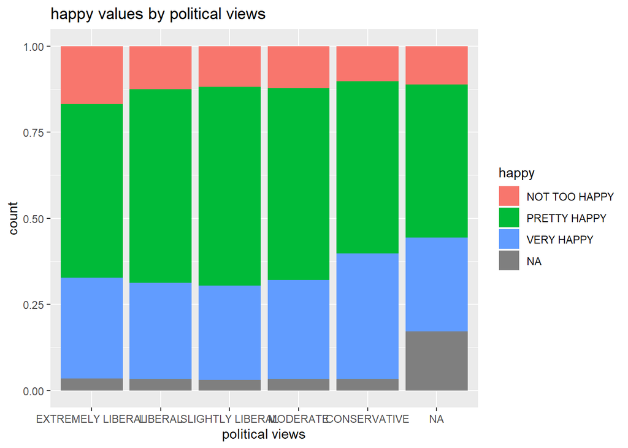

```r
ggplot(happy,aes(x =polviews,fill=happy))+geom_bar(position="fill")+labs(title="happy values by political views", x="political views")
```

The distribution for `happy by political views` is `relatively normal`, with a higher number of moderate respondents. There are a higher number of ‘extremely liberal’ respondents who are ‘not too happy’ and ‘conservative’ respondents who are ‘very happy.’ This data has a high number of NA values, so it may not be an accurate reflection of the population.

Two variables of interest are `HAPPY` and `HEALTH`. Their distributions are as follow:

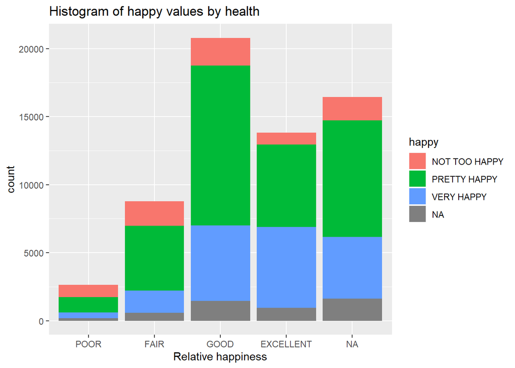

```r
ggplot(happy,aes(health))+geom_bar(aes(fill = happy))+labs(title="Histogram of happy values by health", x="Relative happiness","Number of respondents")+theme()
```

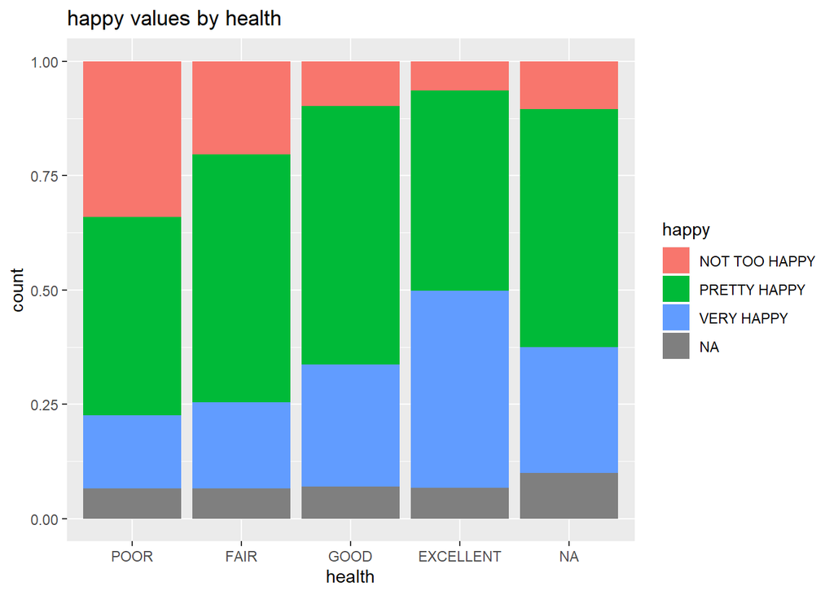

```r
ggplot(happy,aes(x =health,fill=happy))+geom_bar(position="fill")+labs(title="happy values by health", x="health")
```

The distribution for `happy by health` is `left-skewed`, with a higher number of respondents in ‘good’ or ‘excellent’ health. There are a higher number of ‘excellent’ health respondents who are ‘very happy’ and ‘poor’ health respondents who are ‘not too happy.’ This data has a high number of NA values, so it may not be an accurate reflection of the population.

Two variables of interest are `HAPPY` and `MARITAL`. Their distributions are as follow:

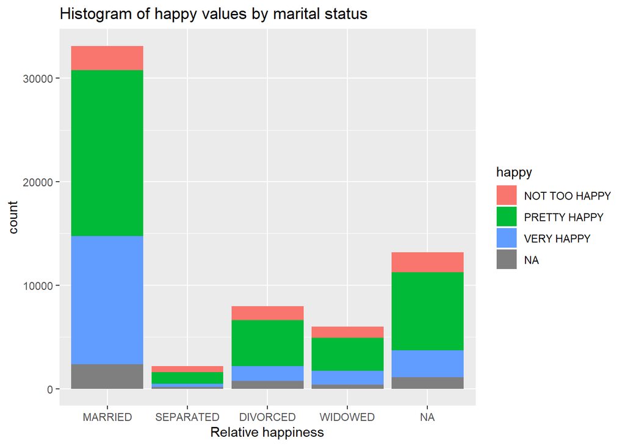

```r
ggplot(happy,aes(marital))+geom_bar(aes(fill = happy))+labs(title="Histogram of happy values by marital status", x="Relative happiness","Number of respondents")+theme()
```

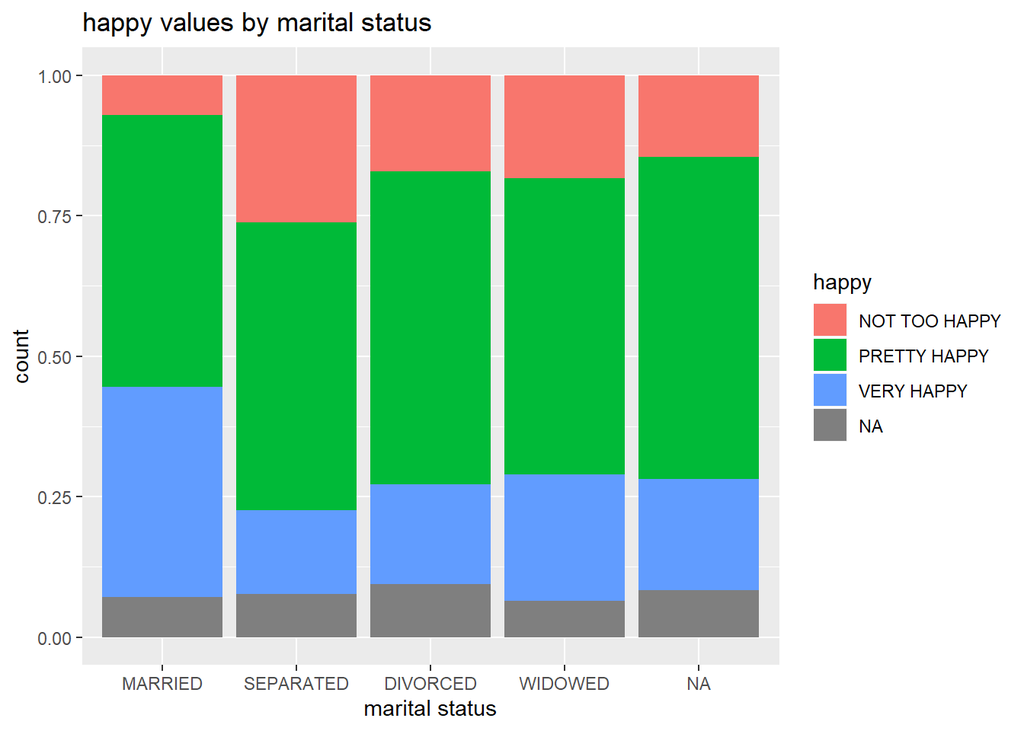

```r
ggplot(happy,aes(x =marital,fill=happy))+geom_bar(position="fill")+labs(title="happy values by marital status", x="marital status")
```

The distribution for `happy by marital status` has a high number of married respondents. There are a higher number of ‘separated’ respondents who are ‘not too happy’ and ‘married’ respondents who are ‘very happy.’ This data has a high number of NA values, so it may not be an accurate reflection of the population.

Two variables of interest are `HAPPY` and `DEGREE`. Their distributions are as follow:

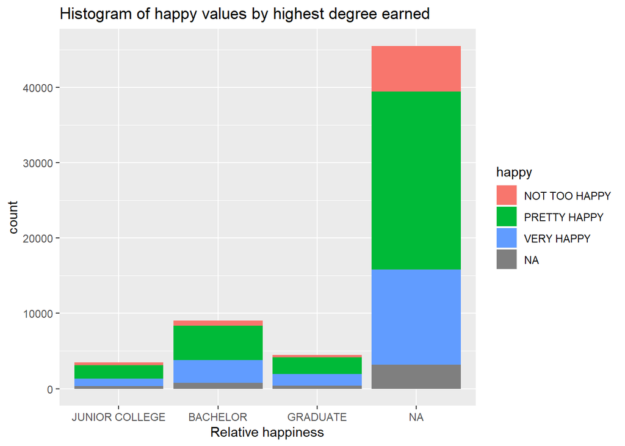

```r
ggplot(happy,aes(degree))+geom_bar(aes(fill = happy))+labs(title="Histogram of happy values by highest degree earned", x="Relative happiness","Number of respondents")+theme()
```

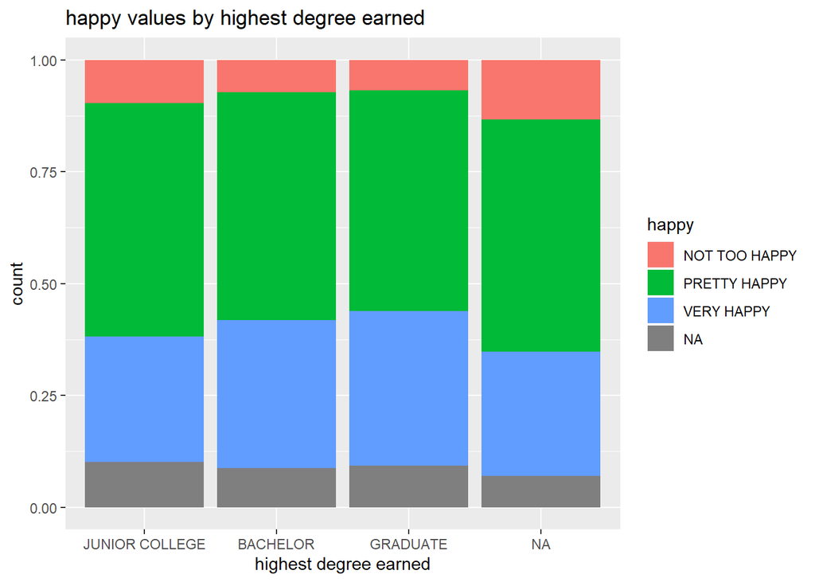

```r
ggplot(happy,aes(x =degree,fill=happy))+geom_bar(position="fill")+labs(title="happy values by highest degree earned", x="highest degree earned")
```

The distribution for `happy by highest degree earned` is `relatively normal`, with the exception that there are an abnormally high number of NA values. Other than the NA values, there seems to be an even distribution of happiness by the highest degree earned, although there are a slightly larger number of respondents with graduate degrees who are ‘very happy’. This data has a high number of NA values, so it may not be an accurate reflection of the population.